# (Ford GoBike System Data)

## by (Youssef Hussein Ahmed)

### Dataset Overview

This data set includes information about individual rides made in a bike-sharing system covering the greater San Francisco Bay area.

```python
# import all packages and set plots to be embedded inline
import numpy as np
import pandas as pd
import matplotlib.pyplot as plt
import seaborn as sb

%matplotlib inline
```

```python
# load and show the dataset
df = pd.read_csv('201902-fordgobike-tripdata.csv')
pd.set_option('display.max_rows', df.shape[0])
pd.set_option('display.max_rows', df.shape[1])
df.head()
```

|  | duration_sec | start_time | end_time | start_station_id | start_station_name | start_station_latitude | start_station_longitude | end_station_id | end_station_name | end_station_latitude | end_station_longitude | bike_id | user_type | member_birth_year | member_gender | bike_share_for_all_trip |
| --- | --- | --- | --- | --- | --- | --- | --- | --- | --- | --- | --- | --- | --- | --- | --- | --- |
| 0 | 52185 | 2019-02-28 17:32:10.1450 | 2019-03-01 08:01:55.9750 | 21.0 | Montgomery St BART Station (Market St at 2nd St) | 37.789625 | -122.400811 | 13.0 | Commercial St at Montgomery St | 37.794231 | -122.402923 | 4902 | Customer | 1984.0 | Male | No |
| 1 | 42521 | 2019-02-28 18:53:21.7890 | 2019-03-01 06:42:03.0560 | 23.0 | The Embarcadero at Steuart St | 37.791464 | -122.391034 | 81.0 | Berry St at 4th St | 37.775880 | -122.393170 | 2535 | Customer | NaN | NaN | No |
| 2 | 61854 | 2019-02-28 12:13:13.2180 | 2019-03-01 05:24:08.1460 | 86.0 | Market St at Dolores St | 37.769305 | -122.426826 | 3.0 | Powell St BART Station (Market St at 4th St) | 37.786375 | -122.404904 | 5905 | Customer | 1972.0 | Male | No |
| 3 | 36490 | 2019-02-28 17:54:26.0100 | 2019-03-01 04:02:36.8420 | 375.0 | Grove St at Masonic Ave | 37.774836 | -122.446546 | 70.0 | Central Ave at Fell St | 37.773311 | -122.444293 | 6638 | Subscriber | 1989.0 | Other | No |
| 4 | 1585 | 2019-02-28 23:54:18.5490 | 2019-03-01 00:20:44.0740 | 7.0 | Frank H Ogawa Plaza | 37.804562 | -122.271738 | 222.0 | 10th Ave at E 15th St | 37.792714 | -122.248780 | 4898 | Subscriber | 1974.0 | Male | Yes |

### What is the structure of your dataset?

```python
df.shape
```

```
(183412, 16)
```

```python
df.dtypes
```

```
duration_sec                 int64
start_time                  object
end_time                    object
start_station_id           float64
start_station_name          object
start_station_latitude     float64
start_station_longitude    float64
end_station_id             float64
end_station_name            object
end_station_latitude       float64
end_station_longitude      float64
bike_id                      int64
user_type                   object
member_birth_year          float64
member_gender               object
bike_share_for_all_trip     object
dtype: object
```

**There is 2 columns need type convert which are:**

- start_time
- end_time

**bike_id** variable has int64 type but should not treat as so.. it should be casted into string type

```python
df.start_time = pd.to_datetime(df.start_time)
df.end_time = pd.to_datetime(df.end_time)
df.bike_id = df.bike_id.astype(str)
df.dtypes
```

```
duration_sec                        int64
start_time                 datetime64[ns]
end_time                   datetime64[ns]
start_station_id                  float64
start_station_name                 object
start_station_latitude            float64
start_station_longitude           float64
end_station_id                    float64
end_station_name                   object
end_station_latitude              float64
end_station_longitude             float64
bike_id                            object
user_type                          object
member_birth_year                 float64
member_gender                      object
bike_share_for_all_trip            object
dtype: object
```

```python
df.duplicated().sum()
```

```
0
```

```python
df.isna().sum()
```

```
duration_sec                  0
start_time                    0
end_time                      0
start_station_id            197
start_station_name          197
start_station_latitude        0
start_station_longitude       0
end_station_id              197
end_station_name            197
end_station_latitude          0
end_station_longitude         0
bike_id                       0
user_type                     0
member_birth_year          8265
member_gender              8265
bike_share_for_all_trip       0
dtype: int64
```

There's 6 columns has missing values which are:

- start_station_id
- start_station_name
- end_station_id
- end_station_name
- member_birth_year
- member_gender

Since the observations that have missing values are relatively few compared to the whole observations of the df, so we can drop them all!

```python
df.dropna(inplace= True)
df.isna().sum()
```

```
duration_sec               0
start_time                 0
end_time                   0
start_station_id           0
start_station_name         0
start_station_latitude     0
start_station_longitude    0
end_station_id             0
end_station_name           0
end_station_latitude       0
end_station_longitude      0
bike_id                    0
user_type                  0
member_birth_year          0
member_gender              0
bike_share_for_all_trip    0
dtype: int64
```

### What is/are the main feature(s) of interest in your dataset?

I think in this dataset **duration_sec** should be our main focus of interest

### What features in the dataset do you think will help support your investigation into your feature(s) of interest?

I think the following features will support my investigation into **duration_sec**:

- start_time
- end_time
- start_station_latitude
- start_station_longitude
- end_station_latitude
- end_station_longitude
- user_type
- member_birth_year
- member_gender
- bike_share_for_all_trip

```python
feat_df = df[['duration_sec', 'start_time', 'end_time', 'start_station_latitude', 'start_station_longitude', 'end_station_latitude', 'end_station_longitude', 'user_type', 'member_birth_year', 'member_gender', 'bike_share_for_all_trip']]
feat_df.head()
```

|  | duration_sec | start_time | end_time | start_station_latitude | start_station_longitude | end_station_latitude | end_station_longitude | user_type | member_birth_year | member_gender | bike_share_for_all_trip |
| --- | --- | --- | --- | --- | --- | --- | --- | --- | --- | --- | --- |
| 0 | 52185 | 2019-02-28 17:32:10.145 | 2019-03-01 08:01:55.975 | 37.789625 | -122.400811 | 37.794231 | -122.402923 | Customer | 1984.0 | Male | No |
| 2 | 61854 | 2019-02-28 12:13:13.218 | 2019-03-01 05:24:08.146 | 37.769305 | -122.426826 | 37.786375 | -122.404904 | Customer | 1972.0 | Male | No |
| 3 | 36490 | 2019-02-28 17:54:26.010 | 2019-03-01 04:02:36.842 | 37.774836 | -122.446546 | 37.773311 | -122.444293 | Subscriber | 1989.0 | Other | No |
| 4 | 1585 | 2019-02-28 23:54:18.549 | 2019-03-01 00:20:44.074 | 37.804562 | -122.271738 | 37.792714 | -122.248780 | Subscriber | 1974.0 | Male | Yes |
| 5 | 1793 | 2019-02-28 23:49:58.632 | 2019-03-01 00:19:51.760 | 37.770407 | -122.391198 | 37.798014 | -122.405950 | Subscriber | 1959.0 | Male | No |

- We should explore each single variable selected above.
- **duration_sec** variable should be our main focus of interest.
- We should explore the effect of each single varible selected above on the duration.

## A- Univariate Exploration

### 1- Distribution "duration_sec"

```
count    174952.000000
mean        704.002744
std        1642.204905
min          61.000000
25%         323.000000
50%         510.000000
75%         789.000000
max       84548.000000
Name: duration_sec, dtype: float64
```

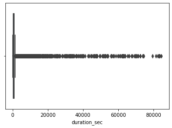

```python
print(feat_df.duration_sec.describe())  # describe to check the 5 number summary
sb.boxplot(x= feat_df.duration_sec);    # boxplot to check outliers
```

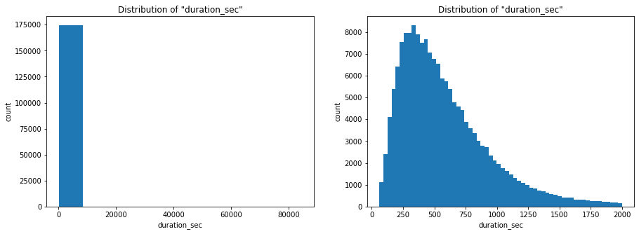

```python
plt.figure(figsize= [15, 5])

plt.subplot(1,2,1)
plt.hist(feat_df.duration_sec)
plt.title('Distribution of "duration_sec"')
plt.xlabel('duration_sec')
plt.ylabel('count')

plt.subplot(1,2,2)
stp= (2e3- 60) / 60
plt.hist(feat_df.duration_sec, bins= np.arange(61, 2e3+stp, stp))
plt.title('Distribution of "duration_sec"')
plt.xlabel('duration_sec')
plt.ylabel('count');
```

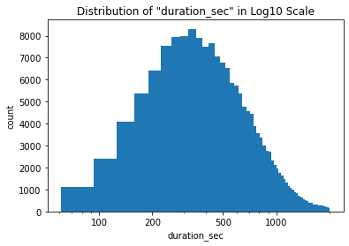

```python
# Log10 scale
stp= (2e3- 60) / 60
plt.hist(feat_df.duration_sec, bins= np.arange(61, 2e3+stp, stp))
plt.xscale('log')

x_ticks= [100, 200, 500, 1000]
plt.xticks(x_ticks, x_ticks)
plt.title('Distribution of "duration_sec" in Log10 Scale')
plt.xlabel('duration_sec')
plt.ylabel('count');
```

- Duration is mostly centered on values that less than 2000 sec.
- Trips number increases starting from around 1000 trip to 8500 trip in duration values up to 400 sec but then starts to decrease to less than 1000 trip in duration values that under 1300 sec.
- Distribution in normal scale seemed to be a little right skewed but in log10 scale seemed to be normally distributed.

### 2- Distribution of "start_time" and "end_time"

```python
feat_df['day'] = feat_df.start_time.apply(lambda dt: dt.weekday())
feat_df['day'] = feat_df.day.apply(lambda d: 'Weekend' if d in [4,5] else 'Weekday')
```

```python
days_type = pd.api.types.CategoricalDtype(ordered= False, categories= feat_df['day'].unique())
feat_df['day'] = feat_df['day'].astype(days_type)
```

```python
feat_df.day.value_counts()
```

```
Weekday    132875
Weekend     42077
Name: day, dtype: int64
```

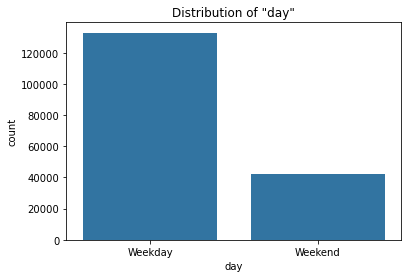

```python
base_color = sb.color_palette()[0]
sb.countplot(data= feat_df, x= 'day', color= base_color)
plt.title('Distribution of "day"');
```

```python
feat_df['start_time'] = feat_df.start_time.apply(lambda dt: int(dt.hour))
feat_df['end_time'] = feat_df.end_time.apply(lambda dt: int(dt.hour))
```

```python
time_bins = [0,4,8,12,16,20,24]
time_labels = ['Late Night', 'Early Morning','Morning','Noon','Evening','Night']
feat_df['start_time'] = pd.cut(feat_df['start_time'], bins= time_bins, labels= time_labels, include_lowest=True)
feat_df['end_time'] = pd.cut(feat_df['end_time'], bins= time_bins, labels= time_labels, include_lowest=True)
feat_df.head()
```

|  | duration_sec | start_time | end_time | start_station_latitude | start_station_longitude | end_station_latitude | end_station_longitude | user_type | member_birth_year | member_gender | bike_share_for_all_trip | day |
| --- | --- | --- | --- | --- | --- | --- | --- | --- | --- | --- | --- | --- |
| 0 | 52185 | Evening | Early Morning | 37.789625 | -122.400811 | 37.794231 | -122.402923 | Customer | 1984.0 | Male | No | Weekday |
| 2 | 61854 | Morning | Early Morning | 37.769305 | -122.426826 | 37.786375 | -122.404904 | Customer | 1972.0 | Male | No | Weekday |
| 3 | 36490 | Evening | Late Night | 37.774836 | -122.446546 | 37.773311 | -122.444293 | Subscriber | 1989.0 | Other | No | Weekday |
| 4 | 1585 | Night | Late Night | 37.804562 | -122.271738 | 37.792714 | -122.248780 | Subscriber | 1974.0 | Male | Yes | Weekday |
| 5 | 1793 | Night | Late Night | 37.770407 | -122.391198 | 37.798014 | -122.405950 | Subscriber | 1959.0 | Male | No | Weekday |

```python
# convert start_time and end_time into ordered categorical types
dayparts = ['Late Night', 'Early Morning','Morning','Noon','Evening','Night']

dayparts_type = pd.api.types.CategoricalDtype(ordered= True, categories= dayparts)
feat_df['start_time'] = feat_df['start_time'].astype(dayparts_type)
feat_df['end_time'] = feat_df['end_time'].astype(dayparts_type)

feat_df.dtypes
```

```
duration_sec                  int64
start_time                 category
end_time                   category
start_station_latitude      float64
start_station_longitude     float64
end_station_latitude        float64
end_station_longitude       float64
user_type                    object
member_birth_year           float64
member_gender                object
bike_share_for_all_trip      object
day                        category
dtype: object
```

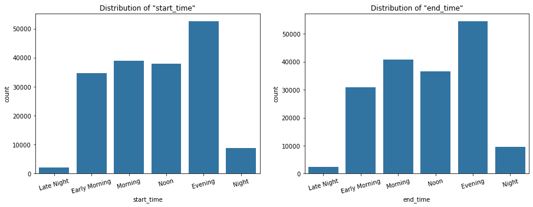

```python
plt.figure(figsize= [15, 5])

plt.subplot(1,2,1)
sb.countplot(data= feat_df, x= 'start_time', color= base_color, order= dayparts_type.categories)
plt.xticks(rotation= 15)
plt.title('Distribution of "start_time"')

plt.subplot(1,2,2)
sb.countplot(data= feat_df, x= 'end_time', color= base_color, order= dayparts_type.categories)
plt.xticks(rotation= 15)
plt.title('Distribution of "end_time"');
```

### 3- Distribution of 'start_station_latitude', 'start_station_longitude', 'end_station_latitude', 'end_station_longitude'

- Since these vars are numerical we just can use histograms.

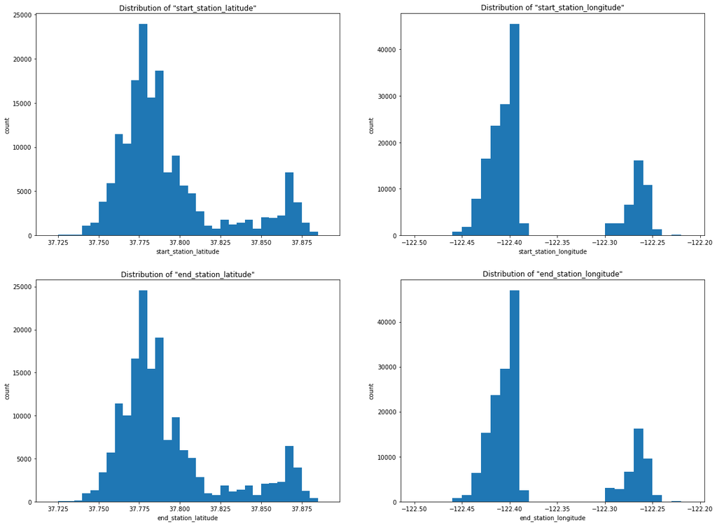

```python
plt.figure(figsize= [20,15])

plt.subplot(2,2,1)
plt.hist(feat_df.start_station_latitude, bins= np.arange(37.72, 37.89, 0.005))
plt.title('Distribution of "start_station_latitude"')
plt.xlabel('start_station_latitude')
plt.ylabel('count')

plt.subplot(2,2,2)
plt.hist(feat_df.start_station_longitude, bins= np.arange(-122.5, -122.2, 0.01))
plt.title('Distribution of "start_station_longitude"')
plt.xlabel('start_station_longitude')
plt.ylabel('count')

plt.subplot(2,2,3)
plt.hist(feat_df.end_station_latitude, np.arange(37.72, 37.89, 0.005))
plt.title('Distribution of "end_station_latitude"')
plt.xlabel('end_station_latitude')
plt.ylabel('count')

plt.subplot(2,2,4)
plt.hist(feat_df.end_station_longitude, bins= np.arange(-122.5, -122.2, 0.01))
plt.title('Distribution of "end_station_longitude"')
plt.xlabel('end_station_longitude')
plt.ylabel('count');
```

- It seems most trips starts from stations at latitudes between (3.755:37.805) and also ends mostly at them.
- While it seems most trips starts from stations at longitudes between (-122.45:-122.4) and also ends mostly at them.

**To me I see this me be a bit confusing so I tried another technique in next few cells**

```python
# add approximate cols of lat_vars values to form 4 unique values and do same to long_vars
step = 0.2
to_bin = lambda x: np.floor(x / step) * step

for var in ['start_station_latitude', 'end_station_latitude']:
    feat_df[var+'_region'] = feat_df[var].map(to_bin)

for var in ['start_station_longitude', 'end_station_longitude']:
    feat_df[var+'_region'] = feat_df[var].map(to_bin)
```

```python
feat_df.start_station_latitude_region.unique(), feat_df.end_station_longitude_region.unique()
```

```
(array([37.6, 37.8, 37.2]), array([-122.6, -122.4, -122. ]))
```

```python
# convert numeric values to string
def to_region(x, long= False):
    '''This function group each unique numeric
        value of latitude or longitude to its appropriate
        lat or long region'''
    if long:
        if x== -122.: return 'long_region3'
        elif x== -122.4: return 'long_region2'
        else: return 'long_region1'
    else:
        if x==37.2: return 'lat_region1'
        elif x==37.6: return 'lat_region2'
        else: return 'lat_region3'

for var in ['start_station_latitude_region', 'end_station_latitude_region']:
    feat_df[var] = feat_df[var].apply(to_region)

for var in ['start_station_longitude_region', 'end_station_longitude_region']:
    feat_df[var] = feat_df[var].apply(to_region, long= True)
```

```python
feat_df.start_station_latitude_region.unique(), feat_df.end_station_longitude_region.unique()
```

```
(array(['lat_region2', 'lat_region3', 'lat_region1'], dtype=object),
 array(['long_region1', 'long_region2', 'long_region3'], dtype=object))
```

```python
# convert lat_long_vars to ordinal types
lat_regions = ['lat_region1', 'lat_region2', 'lat_region3']
long_regions = ['long_region1', 'long_region2', 'long_region3']

lat_regions_type = pd.api.types.CategoricalDtype(ordered= True, categories= lat_regions)
long_regions_type = pd.api.types.CategoricalDtype(ordered= True, categories= long_regions)

for var in ['start_station_latitude_region', 'end_station_latitude_region']:
    feat_df[var] = feat_df[var].astype(lat_regions_type)

for var in ['start_station_longitude_region', 'end_station_longitude_region']:
    feat_df[var] = feat_df[var].astype(long_regions_type)

feat_df.dtypes
```

```
duration_sec                         int64
start_time                        category
end_time                          category
start_station_latitude             float64
start_station_longitude            float64
end_station_latitude               float64
end_station_longitude              float64
user_type                           object
member_birth_year                  float64
member_gender                       object
bike_share_for_all_trip             object
day                               category
start_station_latitude_region     category
end_station_latitude_region       category
start_station_longitude_region    category
end_station_longitude_region      category
dtype: object
```

[figure not shown]

```python
plt.figure(figsize= [20,15])

plt.subplot(2,2,1)
sb.countplot(data= feat_df, x= 'start_station_latitude_region', order= lat_regions_type.categories, color= base_color)
plt.title('Distribution of "start_station_latitude_region"')

plt.subplot(2,2,2)
sb.countplot(data= feat_df, x= 'start_station_longitude_region', order= long_regions_type.categories, color= base_color)
plt.title('Distribution of "start_station_longitude_region"')

plt.subplot(2,2,3)
sb.countplot(data= feat_df, x= 'end_station_latitude_region', order= lat_regions_type.categories, color= base_color)
plt.title('Distribution of "start_station_longitude_region"')

plt.subplot(2,2,4)
sb.countplot(data= feat_df, x= 'end_station_longitude_region', order= long_regions_type.categories, color= base_color)
plt.title('Distribution of "end_station_longitude_region"');
```

- That's more better and make sense to me.
- It seems the largest percentage of trips start from stations in lat_region2 and end also at them.
- While long_region1 and long_region2 have close percentage of the trips that start and end at them.

### 4- Distribution of 'user_type'

```python
# convert user_type to nominal type
users_type = pd.api.types.CategoricalDtype(ordered= False, categories= feat_df.user_type.unique())
feat_df['user_type'] = feat_df['user_type'].astype(users_type)

feat_df['user_type'].dtype
```

```
CategoricalDtype(categories=['Customer', 'Subscriber'], ordered=False)
```

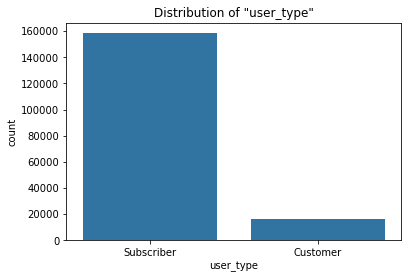

```python
sb.countplot(data= feat_df, x= 'user_type', order= feat_df.user_type.value_counts().index, color= base_color)
plt.xlabel('user_type')
plt.title('Distribution of "user_type"');
```

- It seems the largest percentage of trips are by subscribers

### 5- Distribution of 'member_birth_year'

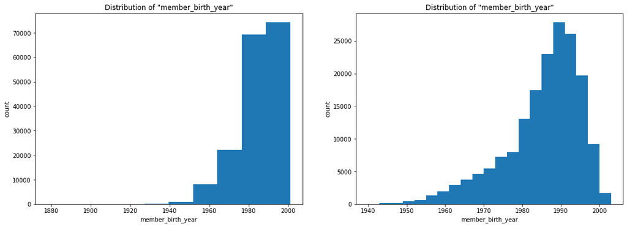

```python
plt.figure(figsize= [18,6])

plt.subplot(1,2,1)
plt.hist(feat_df.member_birth_year)
plt.xlabel('member_birth_year')
plt.ylabel('count')
plt.title('Distribution of "member_birth_year"')

plt.subplot(1,2,2)
plt.hist(feat_df.member_birth_year, bins= np.arange(1940, 2006, 3))
plt.xlabel('member_birth_year')
plt.ylabel('count')
plt.title('Distribution of "member_birth_year"');
```

### 6- Distribution of 'member_gender'

```python
# convert member_gender to nominal type
gender_type = pd.api.types.CategoricalDtype(ordered= False, categories= feat_df.member_gender.unique())
feat_df['member_gender'] = feat_df['member_gender'].astype(gender_type)

feat_df['member_gender'].dtype
```

```
CategoricalDtype(categories=['Male', 'Other', 'Female'], ordered=False)
```

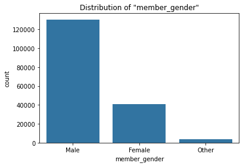

```python
sb.countplot(data= feat_df, x= 'member_gender', order= feat_df.member_gender.value_counts().index, color= base_color)
plt.xlabel('member_gender')
plt.title('Distribution of "member_gender"');
```

- It seems the largest percentages of trips are by males.

### 7- Distribution of 'bike_share_for_all_trip'

```python
# convert member_gender to nominal type
bike_share_type = pd.api.types.CategoricalDtype(ordered= False, categories= feat_df.bike_share_for_all_trip.unique())
feat_df['bike_share_for_all_trip'] = feat_df['bike_share_for_all_trip'].astype(bike_share_type)

feat_df['bike_share_for_all_trip'].dtype
```

```
CategoricalDtype(categories=['No', 'Yes'], ordered=False)
```

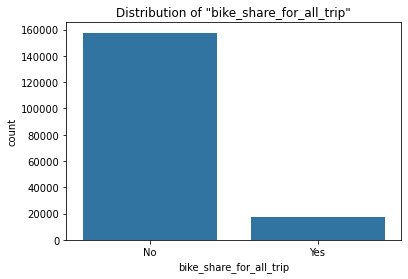

```python
sb.countplot(data= feat_df, x= 'bike_share_for_all_trip', order= feat_df.bike_share_for_all_trip.value_counts().index, color= base_color)
plt.xlabel('bike_share_for_all_trip')
plt.title('Distribution of "bike_share_for_all_trip"');
```

- It seems the largest percentage of trips have no bike share option.

## B- Bivariate Exploration

```python
feat_df.head()
```

|  | duration_sec | start_time | end_time | start_station_latitude | start_station_longitude | end_station_latitude | end_station_longitude | user_type | member_birth_year | member_gender | bike_share_for_all_trip | day | start_station_latitude_region | end_station_latitude_region | start_station_longitude_region | end_station_longitude_region |
| --- | --- | --- | --- | --- | --- | --- | --- | --- | --- | --- | --- | --- | --- | --- | --- | --- |
| 0 | 52185 | Evening | Early Morning | 37.789625 | -122.400811 | 37.794231 | -122.402923 | Customer | 1984.0 | Male | No | Weekday | lat_region2 | lat_region2 | long_region1 | long_region1 |
| 2 | 61854 | Morning | Early Morning | 37.769305 | -122.426826 | 37.786375 | -122.404904 | Customer | 1972.0 | Male | No | Weekday | lat_region2 | lat_region2 | long_region1 | long_region1 |
| 3 | 36490 | Evening | Late Night | 37.774836 | -122.446546 | 37.773311 | -122.444293 | Subscriber | 1989.0 | Other | No | Weekday | lat_region2 | lat_region2 | long_region1 | long_region1 |
| 4 | 1585 | Night | Late Night | 37.804562 | -122.271738 | 37.792714 | -122.248780 | Subscriber | 1974.0 | Male | Yes | Weekday | lat_region3 | lat_region2 | long_region2 | long_region2 |
| 5 | 1793 | Night | Late Night | 37.770407 | -122.391198 | 37.798014 | -122.405950 | Subscriber | 1959.0 | Male | No | Weekday | lat_region2 | lat_region2 | long_region2 | long_region1 |

### 1- Relationship between 'duration_sec' & 'start_time'

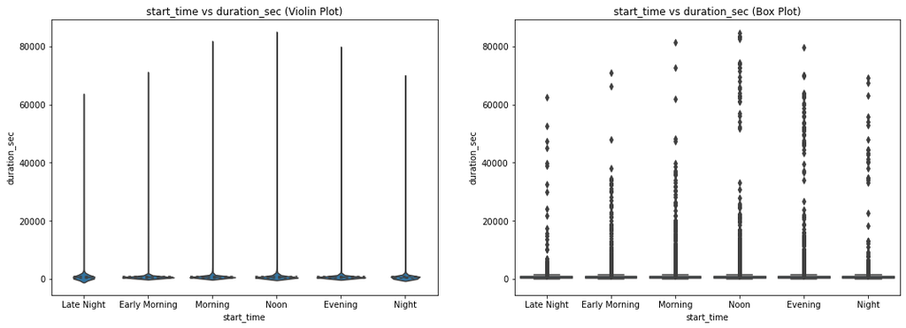

```python
plt.figure(figsize = [18, 6])

plt.subplot(1, 2, 1)
vp = sb.violinplot(data= feat_df, x= 'start_time', y= 'duration_sec', color= base_color, inner='quartile')
plt.title("start_time vs duration_sec (Violin Plot)")

plt.subplot(1, 2, 2)
sb.boxplot(data= feat_df, x= 'start_time', y= 'duration_sec', color= base_color,)
plt.ylim(vp.get_ylim()) # set y-axis limits to be same as left plot
plt.title("start_time vs duration_sec (Box Plot)");
```

- There's a large amount of outliers.
- We can fix that by limit **duration_sec** up to 3k sec only

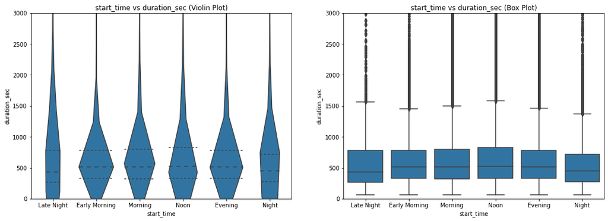

```python
plt.figure(figsize = [18, 6])

plt.subplot(1, 2, 1)
vp = sb.violinplot(data= feat_df, x= 'start_time', y= 'duration_sec', color= base_color, inner='quartile')
plt.ylim(0, 3e3)
plt.title("start_time vs duration_sec (Violin Plot)")

plt.subplot(1, 2, 2)
sb.boxplot(data= feat_df, x= 'start_time', y= 'duration_sec', color= base_color,)
plt.ylim(vp.get_ylim()) # set y-axis limits to be same as left plot
plt.title("start_time vs duration_sec (Box Plot)");
```

- The plots became more clear to interpret.
- All **start_time** dayparts have close median duration values, ranges and IQRs.

### 2- Relationship between 'duration_sec' & 'end_time'

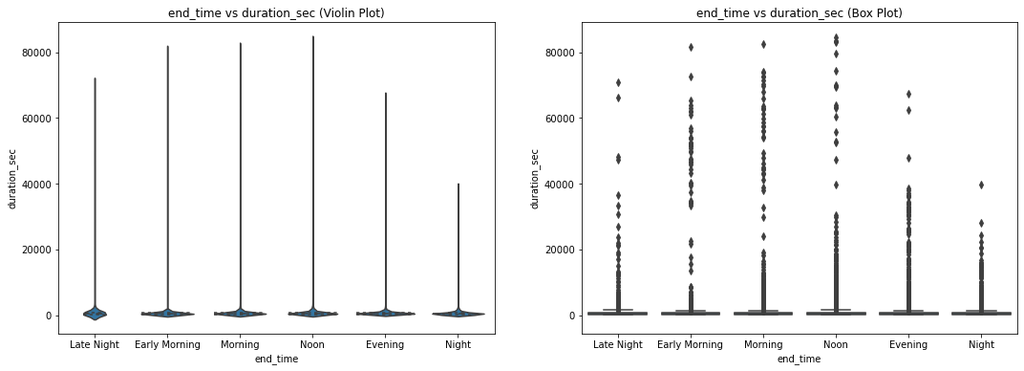

```python
plt.figure(figsize = [18, 6])

plt.subplot(1, 2, 1)
vp = sb.violinplot(data= feat_df, x= 'end_time', y= 'duration_sec', color= base_color, inner='quartile')
plt.title("end_time vs duration_sec (Violin Plot)")

plt.subplot(1, 2, 2)
sb.boxplot(data= feat_df, x= 'end_time', y= 'duration_sec', color= base_color,)
plt.ylim(vp.get_ylim()); # set y-axis limits to be same as left plot
plt.title("end_time vs duration_sec (Box Plot)");
```

- As expected, there's a large amount of outliers same as start_time.
- We can fix that by limit **duration_sec** up to 3k sec only.

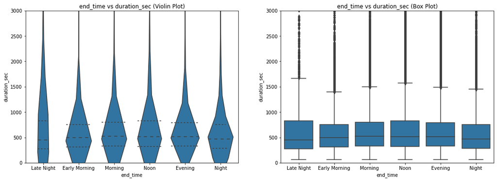

```python
plt.figure(figsize = [18, 6])

plt.subplot(1, 2, 1)
vp = sb.violinplot(data= feat_df, x= 'end_time', y= 'duration_sec', color= base_color, inner='quartile')
plt.ylim(0, 3e3)
plt.title("end_time vs duration_sec (Violin Plot)")

plt.subplot(1, 2, 2)
sb.boxplot(data= feat_df, x= 'end_time', y= 'duration_sec', color= base_color,)
plt.ylim(vp.get_ylim()); # set y-axis limits to be same as left plot
plt.title("end_time vs duration_sec (Box Plot)");
```

- All **end_time** dayparts have close median duration values, ranges and IQRs.
- We know from univariate explorations that most trips are made during evening followed by morning but that doesn't affect the duration of any trip.
- It seems that all trips regardless the daypart have close duration values.

**So there's nothing special about these relationships:**

- duration_sec vs start_time
- duration vs_sec end_time

### 3- Relationship between 'duration_sec' and:

- start_station_latitude
- start_station_longitude
- end_station_latitude
- end_station_longitude

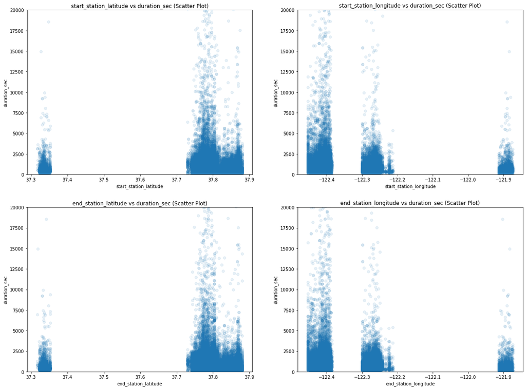

```python
plt.figure(figsize = [20, 15])

plt.subplot(2, 2, 1)
sb.regplot(data= feat_df, x= 'start_station_latitude', y='duration_sec', scatter_kws={'alpha': 1/10}, fit_reg=False)
plt.ylim(0, 2e4)
plt.title("start_station_latitude vs duration_sec (Scatter Plot)")

plt.subplot(2, 2, 2)
sb.regplot(data= feat_df, x= 'start_station_longitude', y='duration_sec', scatter_kws={'alpha': 1/10}, fit_reg=False)
plt.ylim(0, 2e4)
plt.title("start_station_longitude vs duration_sec (Scatter Plot)")

plt.subplot(2, 2, 3)
sb.regplot(data= feat_df, x= 'end_station_latitude', y='duration_sec', scatter_kws={'alpha': 1/10}, fit_reg=False)
plt.ylim(0, 2e4)
plt.title("end_station_latitude vs duration_sec (Scatter Plot)")

plt.subplot(2, 2, 4)
sb.regplot(data= feat_df, x= 'end_station_longitude', y='duration_sec', scatter_kws={'alpha': 1/10}, fit_reg=False)
plt.ylim(0, 2e4)
plt.title("end_station_longitude vs duration_sec (Scatter Plot)");
```

- Bivariate exploration of duration vs latitude and longitude variables actually doesn't add much to the results of univariate exploration of every single variable.
- Most trips starts from stations at latitude region (37.7:37.9) with few number starts from stations at latitude region (37.3:37.5) and ends also at them.
- Most trips starts from stations at longitude regions (-122.48:-122.38) and (-122.3:-122.2) with few number starts from stations at longitude region (-121.92:-121.87) and ends also at them.
- There's no obvious relationship between duration and latitude and longitude variables.

```python
feat_df[['duration_sec', 'start_station_latitude', 'start_station_longitude', 'end_station_latitude', 'end_station_longitude']].corr().duration_sec
```

```
duration_sec               1.000000
start_station_latitude     0.012237
start_station_longitude   -0.040946
end_station_latitude       0.012854
end_station_longitude     -0.041438
Name: duration_sec, dtype: float64
```

**Also, corr coefficients support these results (previous cell).**

### 4- Relationship between 'duration_sec' and 'user_type'

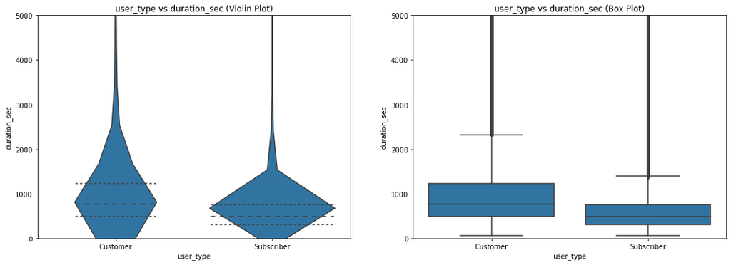

```python
plt.figure(figsize = [18, 6])

plt.subplot(1, 2, 1)
vp = sb.violinplot(data= feat_df, x= 'user_type', y= 'duration_sec', color= base_color, inner='quartile')
plt.ylim(0, 5e3)
plt.title("user_type vs duration_sec (Violin Plot)")

plt.subplot(1, 2, 2)
sb.boxplot(data= feat_df, x= 'user_type', y= 'duration_sec', color= base_color,)
plt.ylim(vp.get_ylim()); # set y-axis limits to be same as left plot
plt.title("user_type vs duration_sec (Box Plot)");
```

### 5- Relationship between 'duration_sec' and 'member_birth_year'

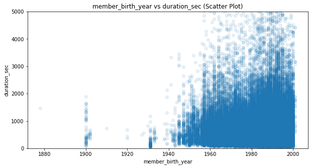

```python
plt.figure(figsize = [10, 5])
sb.regplot(data= feat_df, x= 'member_birth_year', y='duration_sec', scatter_kws={'alpha': 1/10}, fit_reg=False)
plt.ylim(0, 5e3)
plt.title("member_birth_year vs duration_sec (Scatter Plot)");
```

### 6- Relationship between 'duration_sec' and 'member_gender'

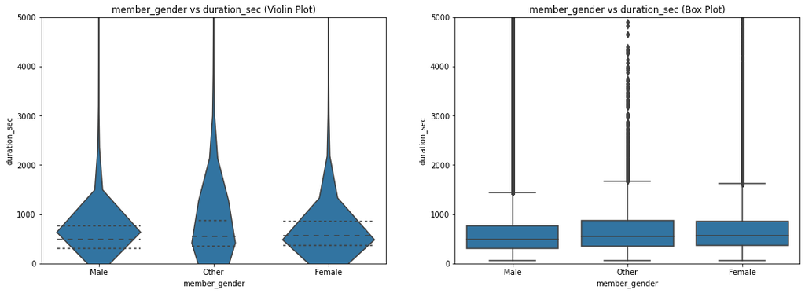

```python
plt.figure(figsize = [18, 6])

plt.subplot(1, 2, 1)
vp = sb.violinplot(data= feat_df, x= 'member_gender', y= 'duration_sec', color= base_color, inner='quartile')
plt.ylim(0, 5e3)
plt.title("member_gender vs duration_sec (Violin Plot)")

plt.subplot(1, 2, 2)
sb.boxplot(data= feat_df, x= 'member_gender', y= 'duration_sec', color= base_color,)
plt.ylim(vp.get_ylim()); # set y-axis limits to be same as left plot
plt.title("member_gender vs duration_sec (Box Plot)");
```

- Here we notice, Different genders have close median duration values, ranges and IQRs.
- We know from univariate exploration that the largest percentage of riders are males but that actually doesn't affect duration.
- There's a big number of outliers here.
- All trips duration regardless member gender are usually about 350 to 800 sec.
- There's nothing special about relationship between 'duration_sec' and 'member_gender'

### 7- Relationship between 'duration_sec' and 'bike_share_for_all_trip'

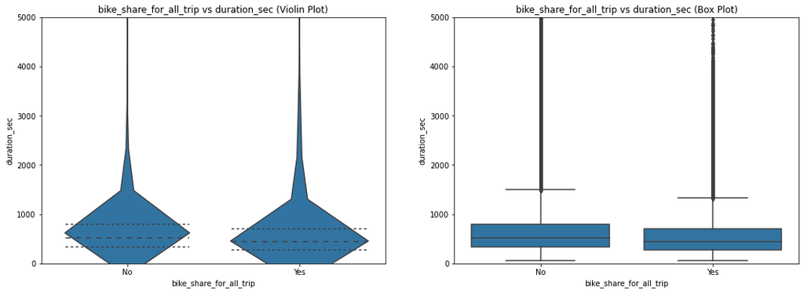

```python
plt.figure(figsize = [18, 6])

plt.subplot(1, 2, 1)
vp = sb.violinplot(data= feat_df, x= 'bike_share_for_all_trip', y= 'duration_sec', color= base_color, inner='quartile')
plt.ylim(0, 5e3)
plt.title("bike_share_for_all_trip vs duration_sec (Violin Plot)")

plt.subplot(1, 2, 2)
sb.boxplot(data= feat_df, x= 'bike_share_for_all_trip', y= 'duration_sec', color= base_color,)
plt.ylim(vp.get_ylim()); # set y-axis limits to be same as left plot
plt.title("bike_share_for_all_trip vs duration_sec (Box Plot)");
```

- Here we notice, Both trips that have sharing bike or not have close median duration values, ranges and IQRs.
- We know from univariate exploration that the largest percentage of trips don't have sharing bike option but that actually doesn't affect duration.
- There's a big number of outliers here.
- All trips duration regardless bike sharing option are usually about 350 to 800 sec.
- There's nothing special about relationship between 'duration_sec' and 'bike_share_for_all_trip'

### 8- Relationship between 'duration_sec' and 'day'

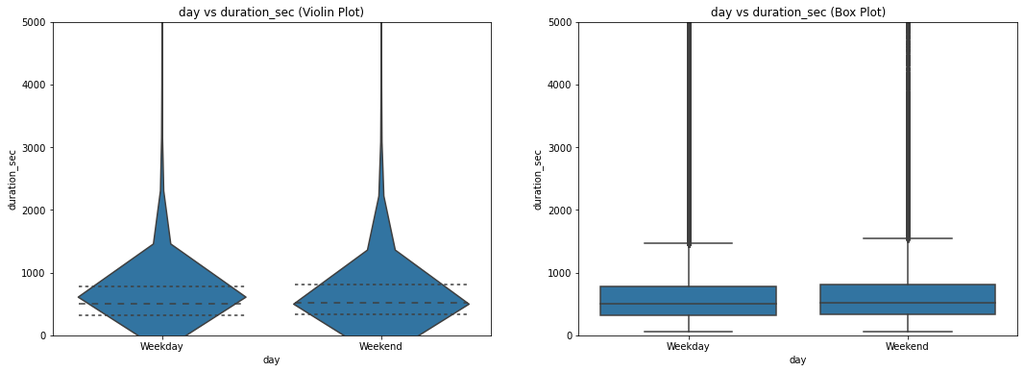

```python
plt.figure(figsize = [18, 6])

plt.subplot(1, 2, 1)
vp = sb.violinplot(data= feat_df, x= 'day', y= 'duration_sec', color= base_color, inner='quartile')
plt.ylim(0, 5e3)
plt.title("day vs duration_sec (Violin Plot)")

plt.subplot(1, 2, 2)
sb.boxplot(data= feat_df, x= 'day', y= 'duration_sec', color= base_color,)
plt.ylim(vp.get_ylim()); # set y-axis limits to be same as left plot
plt.title("day vs duration_sec (Box Plot)");
```

## C- Check relationships between features and each other

```python
feat_df.corr()
```

|  | duration_sec | start_station_latitude | start_station_longitude | end_station_latitude | end_station_longitude | member_birth_year |
| --- | --- | --- | --- | --- | --- | --- |
| duration_sec | 1.000000 | 0.012237 | -0.040946 | 0.012854 | -0.041438 | -0.006041 |
| start_station_latitude | 0.012237 | 1.000000 | -0.678105 | 0.990130 | -0.683552 | -0.075238 |
| start_station_longitude | -0.040946 | -0.678105 | 1.000000 | -0.682598 | 0.992507 | 0.125346 |
| end_station_latitude | 0.012854 | 0.990130 | -0.682598 | 1.000000 | -0.685085 | -0.075339 |
| end_station_longitude | -0.041438 | -0.683552 | 0.992507 | -0.685085 | 1.000000 | 0.126191 |
| member_birth_year | -0.006041 | -0.075238 | 0.125346 | -0.075339 | 0.126191 | 1.000000 |

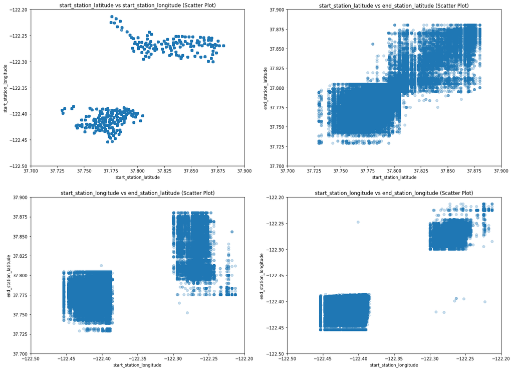

```python
plt.figure(figsize = [20, 15])
lat_lim = [37.7, 37.9]
long_lim = [-122.5, -122.2]

plt.subplot(2, 2, 1)
plt.scatter(data= feat_df, x= 'start_station_latitude', y='start_station_longitude', alpha= 0.25)
plt.xlim(lat_lim)
plt.ylim(long_lim)
plt.xlabel('start_station_latitude')
plt.ylabel('start_station_longitude')
plt.title("start_station_latitude vs start_station_longitude (Scatter Plot)")

plt.subplot(2, 2, 2)
plt.scatter(data= feat_df, x= 'start_station_latitude', y='end_station_latitude', alpha= 0.25)
plt.xlim(lat_lim)
plt.ylim(lat_lim)
plt.xlabel('start_station_latitude')
plt.ylabel('end_station_latitude')
plt.title("start_station_latitude vs end_station_latitude (Scatter Plot)")

plt.subplot(2, 2, 3)
plt.scatter(data= feat_df, x= 'start_station_longitude', y='end_station_latitude', alpha= 0.25)
plt.xlim(long_lim)
plt.ylim(lat_lim)
plt.xlabel('start_station_longitude')
plt.ylabel('end_station_latitude')
plt.title("start_station_longitude vs end_station_latitude (Scatter Plot)")

plt.subplot(2, 2, 4)
plt.scatter(data= feat_df, x= 'start_station_longitude', y='end_station_longitude', alpha= 0.25)
plt.xlim(long_lim)
plt.ylim(long_lim)
plt.xlabel('start_station_longitude')
plt.ylabel('end_station_longitude')
plt.title("start_station_longitude vs end_station_longitude (Scatter Plot)");
```

## D- Multivariate Exploration

### 1- We can start by ploting strong correlations between features encoding duration as third variable

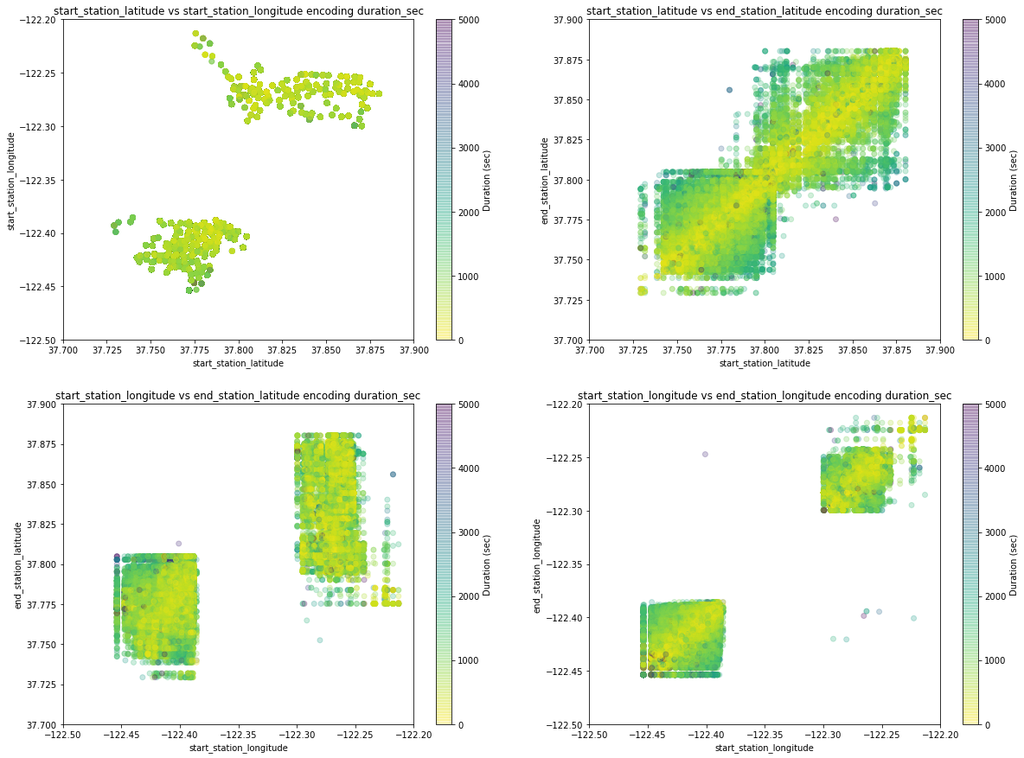

```python
plt.figure(figsize = [20, 15])
lat_lim = [37.7, 37.9]
long_lim = [-122.5, -122.2]
dur_lim = [0, 5e3]

plt.subplot(2, 2, 1)
plt.scatter(data= feat_df, x= 'start_station_latitude', y='start_station_longitude', alpha= 0.25, c= 'duration_sec', cmap= 'viridis_r')
plt.xlim(lat_lim)
plt.ylim(long_lim)
plt.xlabel('start_station_latitude')
plt.ylabel('start_station_longitude')
plt.colorbar(label= 'Duration (sec)')
plt.clim(dur_lim)
plt.title("start_station_latitude vs start_station_longitude encoding duration_sec")

plt.subplot(2, 2, 2)
plt.scatter(data= feat_df, x= 'start_station_latitude', y='end_station_latitude', alpha= 0.25, c= 'duration_sec', cmap= 'viridis_r')
plt.xlim(lat_lim)
plt.ylim(lat_lim)
plt.xlabel('start_station_latitude')
plt.ylabel('end_station_latitude')
plt.colorbar(label= 'Duration (sec)')
plt.clim(dur_lim)
plt.title("start_station_latitude vs end_station_latitude encoding duration_sec")

plt.subplot(2, 2, 3)
plt.scatter(data= feat_df, x= 'start_station_longitude', y='end_station_latitude', alpha= 0.25, c= 'duration_sec', cmap= 'viridis_r')
plt.xlim(long_lim)
plt.ylim(lat_lim)
plt.xlabel('start_station_longitude')
plt.ylabel('end_station_latitude')
plt.colorbar(label= 'Duration (sec)')
plt.clim(dur_lim)
plt.title("start_station_longitude vs end_station_latitude encoding duration_sec")

plt.subplot(2, 2, 4)
plt.scatter(data= feat_df, x= 'start_station_longitude', y='end_station_longitude', alpha= 0.25, c= 'duration_sec', cmap= 'viridis_r')
plt.xlim(long_lim)
plt.ylim(long_lim)
plt.xlabel('start_station_longitude')
plt.ylabel('end_station_longitude')
plt.colorbar(label= 'Duration (sec)')
plt.clim(dur_lim)
plt.title("start_station_longitude vs end_station_longitude encoding duration_sec");
```

- As mentioned before, these features doesn't affect the duration.
- The previous plot supported these results that duration values stayed the same regardless the values of lattitude and longitude varibles values.

### 2- Relationship between 'member_birth_year' & 'duration_sec' encoding 'user_type' (nominal) using color

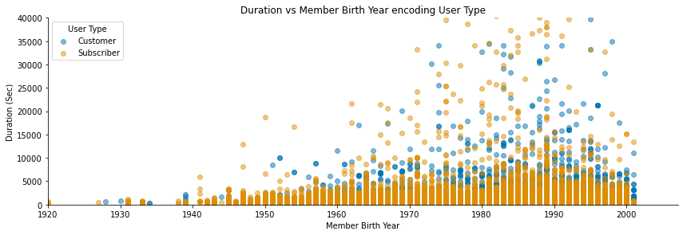

```python
g= sb.FacetGrid(data= feat_df, hue= 'user_type', height= 4, aspect= 3, palette= 'colorblind')
# Qualitative (all up to 6 colors): 'deep', 'pastel', 'dark', 'muted', 'bright', 'colorblind'
g.map(sb.regplot, 'member_birth_year', 'duration_sec', fit_reg= False, scatter_kws={'alpha': 0.5});
plt.legend(title= 'User Type')
plt.xlim(1920)
plt.ylim(0, 4e4)
plt.title('Duration vs Member Birth Year encoding User Type')
plt.xlabel('Member Birth Year')
plt.ylabel('Duration (Sec)');
```